# CMSC320_Final_Project

```python
import pandas as pd
from sklearn.model_selection import train_test_split
from sklearn.linear_model import LogisticRegression
from sklearn.metrics import accuracy_score
import warnings
warnings.filterwarnings("ignore") #to ignore warnings

df = constructor_standings.groupby(['raceId', 'constructorId'])['points'].sum().reset_index()

# Get the winner per race
df['winner_constructor'] = df.groupby('raceId')['points'].transform(lambda x: x.idxmax())

# Pivot the data to have constructors as columns
df_pivoted = df.pivot(index='raceId', columns='constructorId', values='points')
df_pivoted['winner_constructor'] = df.groupby('raceId')['points'].transform(lambda x: x.idxmax())

# Fill NA values with 0
df_pivoted.fillna(0, inplace=True)


# Prepare the data
X = df_pivoted.drop(columns=['winner_constructor'])
y = df_pivoted['winner_constructor']

# Convert y to integers (necessary for logistic regression)

y = y.astype(int)

# Split the data
X_train, X_test, y_train, y_test = train_test_split(X, y, test_size=0.2, random_state=42)

# Train the model
model = LogisticRegression(solver='liblinear', multi_class='ovr')  # Use 'ovr' for multi-class
model.fit(X_train, y_train)

# Predict on the test set
y_pred = model.predict(X_test)

# Evaluate the model
accuracy = accuracy_score(y_test, y_pred)
print(f"Accuracy: {accuracy}")
```

```
Accuracy: 0.8333333333333334
```

```python
from sklearn.model_selection import KFold
from sklearn.metrics import accuracy_score, recall_score, precision_score, f1_score
import numpy as np
from sklearn.linear_model import LogisticRegression


k = 5

# Initialize KFold
kf = KFold(n_splits=k, shuffle=True, random_state=42)

# Initialize lists to store evaluation metrics for each fold
accuracy_scores = []
recall_scores = []
precision_scores = []
f1_scores = []

# Perform k-fold cross-validation
for train_index, test_index in kf.split(X):
    X_train, X_test = X.iloc[train_index], X.iloc[test_index]
    y_train, y_test = y.iloc[train_index], y.iloc[test_index]

    # Train the model
    model = LogisticRegression(solver='liblinear', multi_class='ovr')
    model.fit(X_train, y_train)

    # Make predictions
    y_pred = model.predict(X_test)

    # Evaluate the model
    accuracy = accuracy_score(y_test, y_pred)
    recall = recall_score(y_test, y_pred, average='weighted')
    precision = precision_score(y_test, y_pred, average='weighted')
    f1 = f1_score(y_test, y_pred, average='weighted')

    # Store the evaluation metrics
    accuracy_scores.append(accuracy)
    recall_scores.append(recall)
    precision_scores.append(precision)
    f1_scores.append(f1)

# Print the average evaluation metrics across all folds
print(f"Average Accuracy: {np.mean(accuracy_scores)}")
print(f"Average Recall: {np.mean(recall_scores)}")
print(f"Average Precision: {np.mean(precision_scores)}")
print(f"Average F1-score: {np.mean(f1_scores)}")
```

```
Average Accuracy: 0.8331465026201867
Average Recall: 0.8331465026201867
Average Precision: 0.8844287124738253
Average F1-score: 0.8312043663533754
```

```python
# prompt: generate a random forest model based to predict the constructor winners based on the input features

from sklearn.model_selection import train_test_split
from sklearn.ensemble import RandomForestClassifier
from sklearn.metrics import accuracy_score, classification_report
# Assuming 'results' DataFrame is already available from previous code.
# Prepare the data
# Assuming 'constructorId' is the target variable
# You need to select the relevant features for prediction (X)
# and the target variable (y)

# Example features: raceId, driverId, points, laps
X = results[['raceId', 'driverId', 'points', 'laps']]
y = results['constructorId']

# Split the data into training and testing sets
X_train, X_test, y_train, y_test = train_test_split(X, y, test_size=0.2, random_state=42)

# Initialize and train the RandomForestClassifier model
model = RandomForestClassifier(n_estimators=100, random_state=42)  # You can adjust n_estimators
model.fit(X_train, y_train)

# Make predictions on the test set
y_pred = model.predict(X_test)



# Evaluate the model
accuracy = accuracy_score(y_test, y_pred)
print(f'Accuracy: {accuracy}')
```

```
Accuracy: 0.8546380090497737
```

```python
# prompt: now print the recall precision and the f1 score for the random forest model

from sklearn.metrics import recall_score, precision_score, f1_score

recall = recall_score(y_test, y_pred, average='weighted')
precision = precision_score(y_test, y_pred, average='weighted')
f1 = f1_score(y_test, y_pred, average='weighted')

print(f"Recall: {recall}")
print(f"Precision: {precision}")
print(f"F1 Score: {f1}")
```

```
Recall: 0.8546380090497737
Precision: 0.8568969317758227
F1 Score: 0.8529362727954798
```

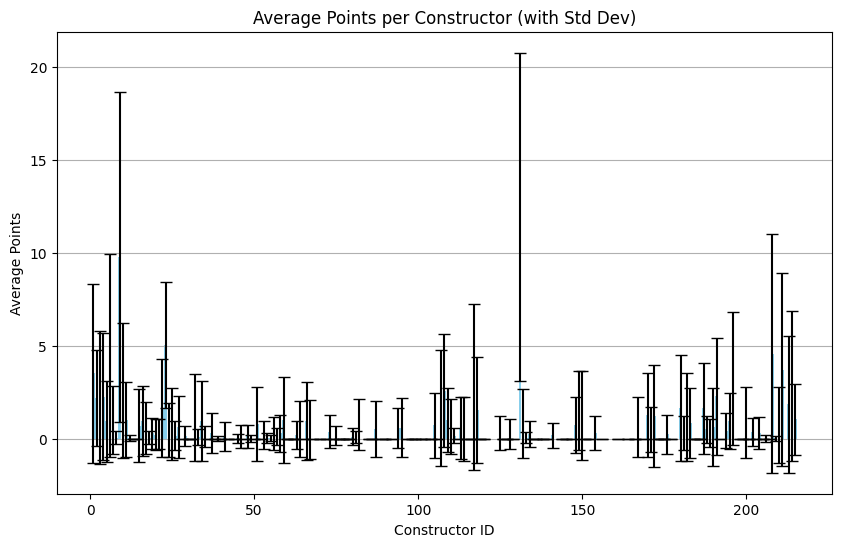

```python
constructor_summary = results.groupby('constructorId')['points'].agg(['mean', 'std']).reset_index()

plt.figure(figsize=(10, 6))
plt.bar(constructor_summary['constructorId'], constructor_summary['mean'], yerr=constructor_summary['std'], color='skyblue', capsize=4)
plt.title('Average Points per Constructor (with Std Dev)')
plt.xlabel('Constructor ID')
plt.ylabel('Average Points')
plt.grid(axis='y')
plt.show()
```

This plot shows how points vary across constructors. We can see that there are so many values for points that that bottom half looks cluttered, but it is clear that we can see more frequent point totals towards the bottom since 0 is very common, and towards the top for the most dominant drivers over the past few years

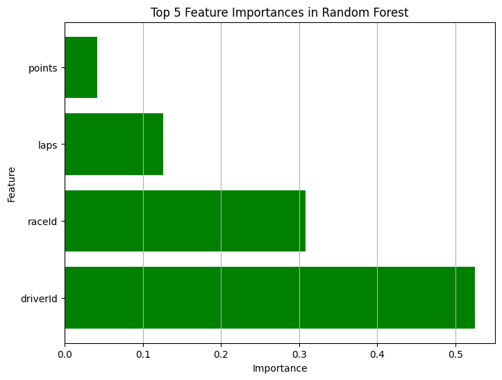

```python
importances = pd.DataFrame({
    'Feature': X.columns,
    'Importance': model.feature_importances_
}).sort_values(by='Importance', ascending=False)

# Select top 5 features for simplicity
top_features = importances.head(5)

plt.figure(figsize=(8, 6))
plt.barh(top_features['Feature'], top_features['Importance'], color='green')
plt.title('Top 5 Feature Importances in Random Forest')
plt.xlabel('Importance')
plt.ylabel('Feature')
plt.grid(axis='x')
plt.show()
```

What we can see from this graph is the importance of a specific feature in our random foreset model, where the driverId was very important in calculating the constructor winners, while the least important was points and laps. It is interesting that raceId was important, maybe symbolizing that certain races benefit certain drivers in F1.

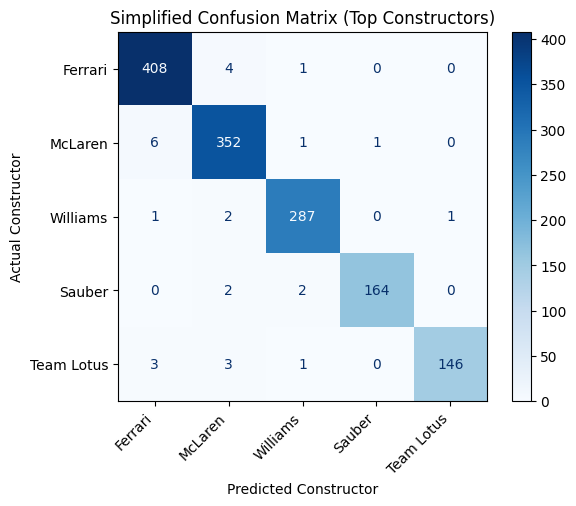

```python
from sklearn.metrics import confusion_matrix, ConfusionMatrixDisplay

# Map constructorId to constructor names
constructor_names = constructors.set_index('constructorId')['name'].to_dict()

# Filter for constructors with most data points
most_common = y_test.value_counts().head(5).index
filtered_y_test = y_test[y_test.isin(most_common)]
filtered_y_pred = y_pred[y_test.isin(most_common)]

# Map IDs to names for better readability
mapped_labels = [constructor_names[cid] for cid in most_common]

# Generate confusion matrix
cm = confusion_matrix(filtered_y_test, filtered_y_pred, labels=most_common)
disp = ConfusionMatrixDisplay(confusion_matrix=cm, display_labels=mapped_labels)

plt.figure(figsize=(10, 8))
disp.plot(cmap='Blues', values_format='d')
plt.title('Simplified Confusion Matrix (Top Constructors)')
plt.xlabel('Predicted Constructor')
plt.ylabel('Actual Constructor')
plt.xticks(rotation=45, ha='right')  # Rotate x-axis labels for readability
plt.show()
```

Whats important to see here in comparison to other graphs is both the fact that our model does not get confused that much and that we are able to correctly predict constructors, but also the fact that for all of the wrong predictions, they are not that high on any one square, showing that the error isn't biased towards one square. This means our model is performing well.

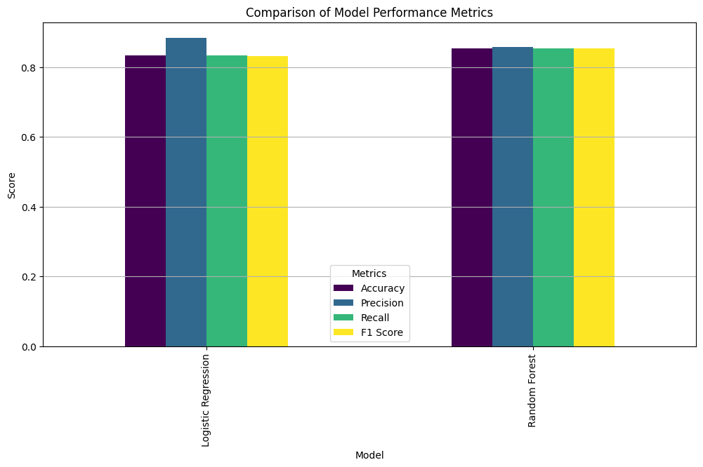

```python
metrics = {
    'Accuracy': [np.mean(accuracy_scores), accuracy],
    'Precision': [np.mean(precision_scores), precision],
    'Recall': [np.mean(recall_scores), recall],
    'F1 Score': [np.mean(f1_scores), f1]
}
metrics_df = pd.DataFrame(metrics, index=['Logistic Regression', 'Random Forest'])

metrics_df.plot(kind='bar', figsize=(12, 6), colormap='viridis')
plt.title('Comparison of Model Performance Metrics')
plt.xlabel('Model')
plt.ylabel('Score')
plt.legend(title='Metrics', loc='best')
plt.grid(axis='y')
plt.show()
```

High accuracy, precision, recall, and F1 score collectively indicate that the model is effective in making correct predictions and managing trade-offs between false positives and false negatives. High precision shows the model's reliability in identifying true winners without overestimating them, while high recall demonstrates its ability to capture most actual winners without missing key cases. The F1 score balances these aspects, confirming the model's robustness in both correctness and completeness. Overall, these metrics show that the model is not only identifying the correct constructors accurately but also minimizing errors, making it highly reliable for predicting F1 race outcomes.

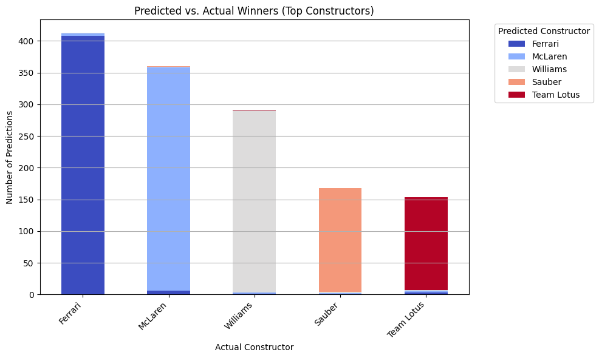

```python
# Map constructorId to constructor names
constructor_names = constructors.set_index('constructorId')['name'].to_dict()

# Filter for most common constructors
top_actual = predictions['Actual'].value_counts().head(5).index
mapped_labels = [constructor_names[cid] for cid in top_actual]

# Aggregate counts for Actual vs Predicted constructors
race_counts = predictions.groupby(['Actual', 'Predicted']).size().unstack(fill_value=0)

# Filter rows and columns for the top constructors
race_counts = race_counts.loc[top_actual, top_actual]

# Update row and column labels with constructor names
race_counts.index = [constructor_names[cid] for cid in race_counts.index]
race_counts.columns = [constructor_names[cid] for cid in race_counts.columns]

# Plot the bar chart
race_counts.plot(kind='bar', stacked=True, figsize=(10, 6), colormap='coolwarm')
plt.title('Predicted vs. Actual Winners (Top Constructors)')
plt.xlabel('Actual Constructor')
plt.ylabel('Number of Predictions')
plt.legend(title='Predicted Constructor', bbox_to_anchor=(1.05, 1), loc='upper left')
plt.xticks(rotation=45, ha='right')  # Rotate x-axis labels for readability
plt.grid(axis='y')
plt.tight_layout()
plt.show()
```